# Nubank Data Challenge - Exploratory Analysis

## by Adriano Freitas

- Probability of default
- Probability of fraud
- Probability of spending

In the end, these algorithms will help us build a template to approve or not a client and set an initial limit for your card.

## Checking Missing values

Let's take a look inside the missing values on dataset

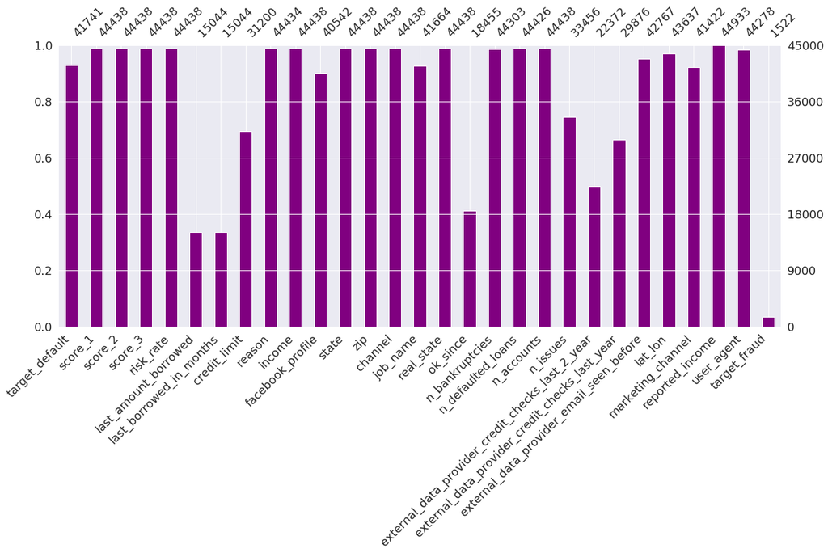

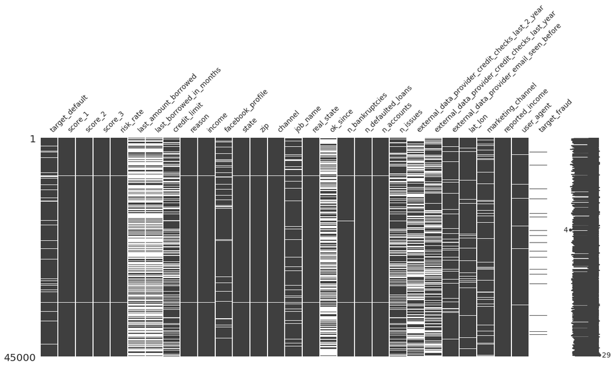

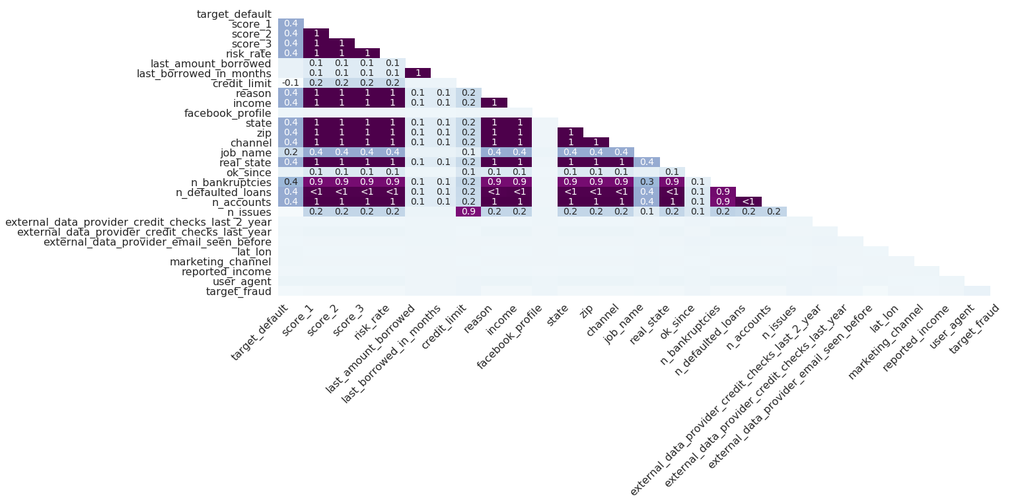

## Pearson correlation matrix

As we can see, there is no much linear correlation between continuous features, except for some calculated ones.

```
Text(0.5,1.05,'Pearson correlation of continuous features')
```

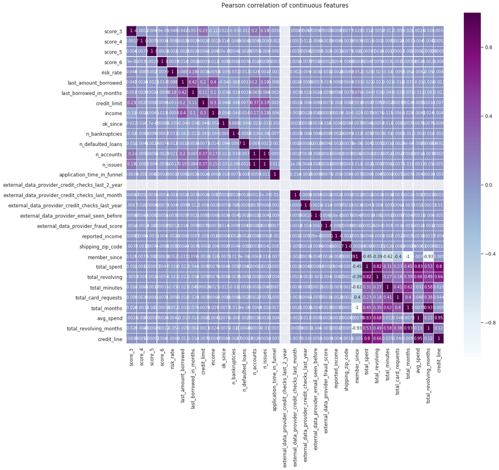

## Default Analysis

```
AxesSubplot(0.125,0.125;0.775x0.755)
```

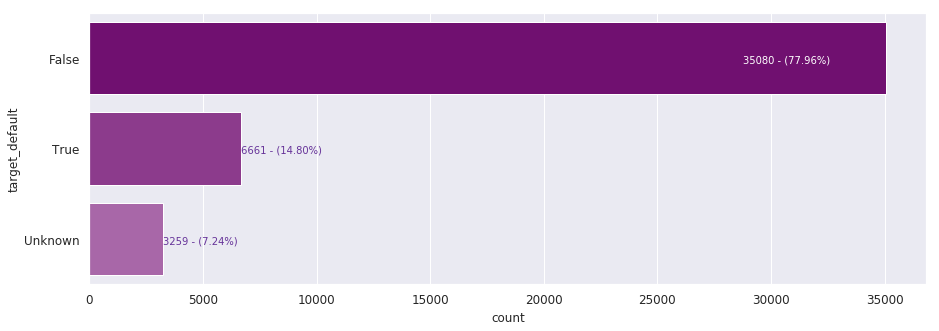

### Unkown data

There is a small number of observations on our dataset wich we don't know if was defaulted or not, let's exclude them

```
AxesSubplot(0.125,0.125;0.775x0.755)
```

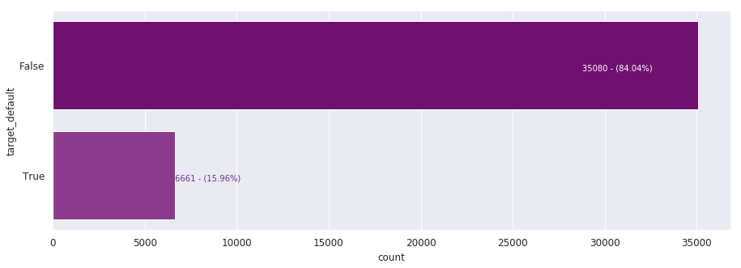

### Deeper default analysis

Let's take a close look into the default data, so let's separate only default data into another dataframe.

### Default history

```
AxesSubplot(0.125,0.125;0.775x0.755)
AxesSubplot(0.125,0.125;0.775x0.755)
AxesSubplot(0.125,0.125;0.775x0.755)
```

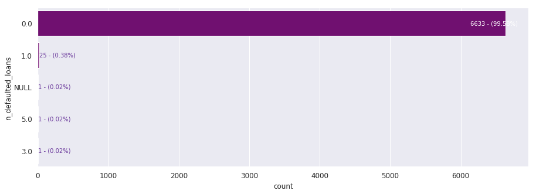

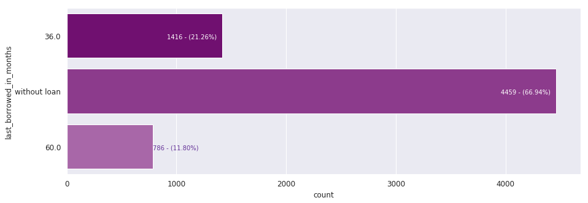

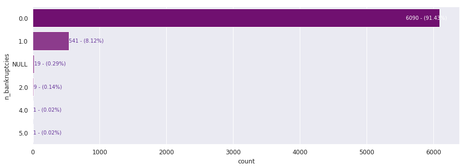

### Income

Let's analyse the default against the income

```
AxesSubplot(0.125,0.125;0.775x0.755)
```

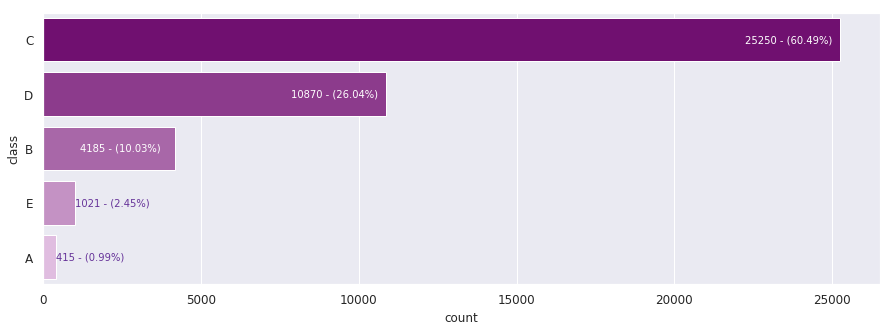

```
AxesSubplot(0.125,0.125;0.775x0.755)
```

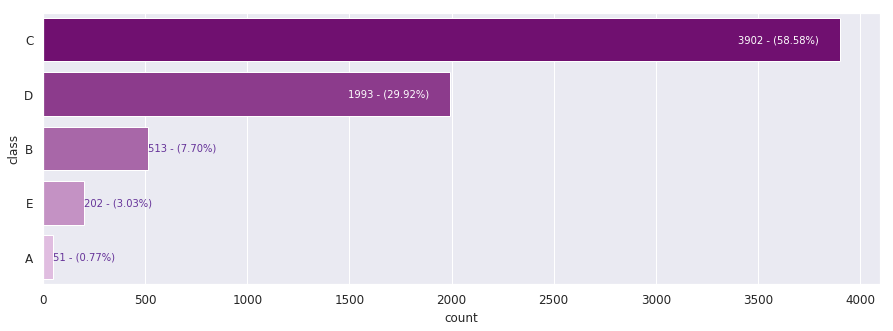

## Fraud Analysis

```
AxesSubplot(0.125,0.125;0.775x0.755)
```

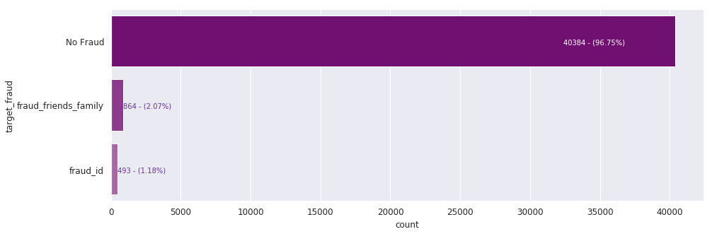

### Fraud loss over the time

```
(1357, 53)
```

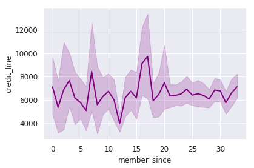

### Fraud vs Default

Let's take a look into only the subset of our data that refers to fraud. How the default is present in this piece of data?

```
AxesSubplot(0.125,0.125;0.775x0.755)
```

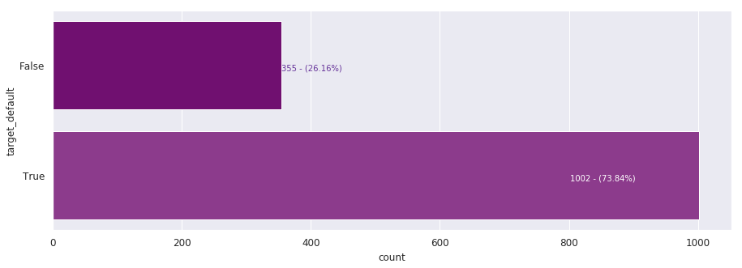

### Default without fraud

As we can see, almost 74% of our frauds end in default. What is an expected behavior.

We need to take care of removing fraud cases from our analysis when talking about default. Makes no sense trying to predict the probability of default (PD) when dealing with a fraud case, once we already know most of the frauds are made with intention of default.

Ideally, the fraud analysis will run before the PD analysis, so a default caused by a fraud is, first of all, a mistake in fraud analysis.

From this point on, when analyzing PD, we will always look for a view of the dataset without fraud.

```
AxesSubplot(0.125,0.125;0.775x0.755)
```

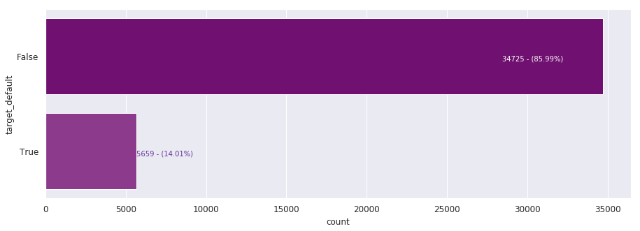

## Value Spend vs Income

### Average spend vs Income

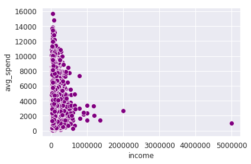

### Total spend vs Income

Here we have to be careful because some people have more or less time as clients.

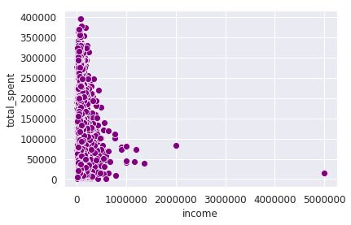

## Distribution of scores

Here we can see that the distribution of scores is normalized, as decribed in https://www.nubank.com.br/perguntas, section: "Tenho o nome "limpo" e não fui aprovado na análise do Nubank. Por que?".

### Score 3

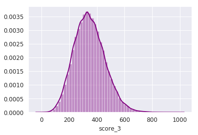

### Score 4

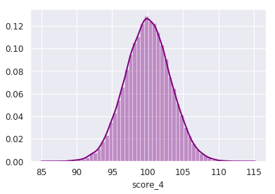

### Score 6

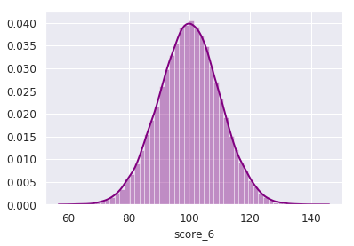

### Risk Rate

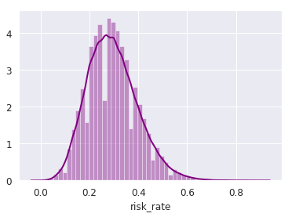

## Customers

### Evolution of customers in time

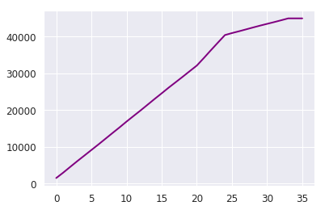

### How many customers were approved by month

It appears that a mistake was made on month 20th and many customers have been approved, and now to compensate customers are being approved less than normal

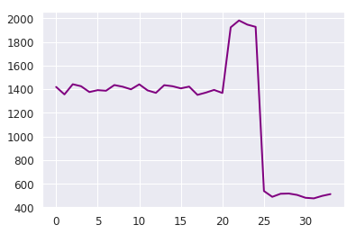

### How many customers approved became defaulters

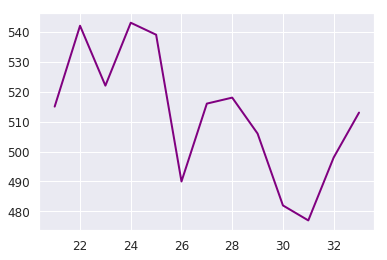

# Reflection

As we can see, it will be a challenging task to predict what has been proposed, because there are few samples of fraud and default in the data set. This reflects the great work that Nubank is doing to prevent this.